# Risk Factor Analysis

## Outcome Variable

**Outcome Variable:** ever_wasted

## Predictor Variables

**Intervention Variable:** mage

**Adjustment Set:**

unadjusted

## Stratifying Variables

The analysis was stratified on these variable(s):

- agecat
- studyid
- country

## Data Summary

| agecat | studyid | country | mage | ever_wasted | n_cell | n | outcome_variable |
| --- | --- | --- | --- | --- | --- | --- | --- |
| 0-24 months | ki0047075b-MAL-ED | BANGLADESH | [20-30) | 0 | 130 | 263 | ever_wasted |
| 0-24 months | ki0047075b-MAL-ED | BANGLADESH | [20-30) | 1 | 50 | 263 | ever_wasted |
| 0-24 months | ki0047075b-MAL-ED | BANGLADESH | <20 | 0 | 18 | 263 | ever_wasted |
| 0-24 months | ki0047075b-MAL-ED | BANGLADESH | <20 | 1 | 19 | 263 | ever_wasted |
| 0-24 months | ki0047075b-MAL-ED | BANGLADESH | >=30 | 0 | 28 | 263 | ever_wasted |
| 0-24 months | ki0047075b-MAL-ED | BANGLADESH | >=30 | 1 | 18 | 263 | ever_wasted |
| 0-24 months | ki0047075b-MAL-ED | BRAZIL | [20-30) | 0 | 127 | 233 | ever_wasted |
| 0-24 months | ki0047075b-MAL-ED | BRAZIL | [20-30) | 1 | 12 | 233 | ever_wasted |
| 0-24 months | ki0047075b-MAL-ED | BRAZIL | <20 | 0 | 40 | 233 | ever_wasted |
| 0-24 months | ki0047075b-MAL-ED | BRAZIL | <20 | 1 | 3 | 233 | ever_wasted |
| 0-24 months | ki0047075b-MAL-ED | BRAZIL | >=30 | 0 | 46 | 233 | ever_wasted |
| 0-24 months | ki0047075b-MAL-ED | BRAZIL | >=30 | 1 | 5 | 233 | ever_wasted |
| 0-24 months | ki0047075b-MAL-ED | INDIA | [20-30) | 0 | 99 | 249 | ever_wasted |
| 0-24 months | ki0047075b-MAL-ED | INDIA | [20-30) | 1 | 95 | 249 | ever_wasted |
| 0-24 months | ki0047075b-MAL-ED | INDIA | <20 | 0 | 15 | 249 | ever_wasted |
| 0-24 months | ki0047075b-MAL-ED | INDIA | <20 | 1 | 19 | 249 | ever_wasted |
| 0-24 months | ki0047075b-MAL-ED | INDIA | >=30 | 0 | 16 | 249 | ever_wasted |
| 0-24 months | ki0047075b-MAL-ED | INDIA | >=30 | 1 | 5 | 249 | ever_wasted |
| 0-24 months | ki0047075b-MAL-ED | NEPAL | [20-30) | 0 | 130 | 240 | ever_wasted |
| 0-24 months | ki0047075b-MAL-ED | NEPAL | [20-30) | 1 | 59 | 240 | ever_wasted |
| 0-24 months | ki0047075b-MAL-ED | NEPAL | <20 | 0 | 2 | 240 | ever_wasted |
| 0-24 months | ki0047075b-MAL-ED | NEPAL | <20 | 1 | 3 | 240 | ever_wasted |
| 0-24 months | ki0047075b-MAL-ED | NEPAL | >=30 | 0 | 34 | 240 | ever_wasted |
| 0-24 months | ki0047075b-MAL-ED | NEPAL | >=30 | 1 | 12 | 240 | ever_wasted |
| 0-24 months | ki0047075b-MAL-ED | PERU | [20-30) | 0 | 139 | 302 | ever_wasted |
| 0-24 months | ki0047075b-MAL-ED | PERU | [20-30) | 1 | 14 | 302 | ever_wasted |
| 0-24 months | ki0047075b-MAL-ED | PERU | <20 | 0 | 74 | 302 | ever_wasted |
| 0-24 months | ki0047075b-MAL-ED | PERU | <20 | 1 | 8 | 302 | ever_wasted |
| 0-24 months | ki0047075b-MAL-ED | PERU | >=30 | 0 | 62 | 302 | ever_wasted |
| 0-24 months | ki0047075b-MAL-ED | PERU | >=30 | 1 | 5 | 302 | ever_wasted |

[output cut: 450 more lines]

The following strata were considered:

- agecat: 0-24 months, studyid: ki0047075b-MAL-ED, country: BANGLADESH
- agecat: 0-24 months, studyid: ki0047075b-MAL-ED, country: BRAZIL
- agecat: 0-24 months, studyid: ki0047075b-MAL-ED, country: INDIA
- agecat: 0-24 months, studyid: ki0047075b-MAL-ED, country: NEPAL
- agecat: 0-24 months, studyid: ki0047075b-MAL-ED, country: PERU
- agecat: 0-24 months, studyid: ki0047075b-MAL-ED, country: SOUTH AFRICA
- agecat: 0-24 months, studyid: ki0047075b-MAL-ED, country: TANZANIA, UNITED REPUBLIC OF
- agecat: 0-24 months, studyid: ki1000108-CMC-V-BCS-2002, country: INDIA
- agecat: 0-24 months, studyid: ki1000108-IRC, country: INDIA
- agecat: 0-24 months, studyid: ki1000109-EE, country: PAKISTAN
- agecat: 0-24 months, studyid: ki1000304b-SAS-CompFeed, country: INDIA
- agecat: 0-24 months, studyid: ki1000304b-SAS-FoodSuppl, country: INDIA
- agecat: 0-24 months, studyid: ki1017093-NIH-Birth, country: BANGLADESH
- agecat: 0-24 months, studyid: ki1017093b-PROVIDE, country: BANGLADESH
- agecat: 0-24 months, studyid: ki1017093c-NIH-Crypto, country: BANGLADESH
- agecat: 0-24 months, studyid: ki1066203-TanzaniaChild2, country: TANZANIA, UNITED REPUBLIC OF
- agecat: 0-24 months, studyid: ki1101329-Keneba, country: GAMBIA
- agecat: 0-24 months, studyid: ki1112895-Guatemala BSC, country: GUATEMALA
- agecat: 0-24 months, studyid: ki1112895-iLiNS-Zinc, country: BURKINA FASO
- agecat: 0-24 months, studyid: ki1113344-GMS-Nepal, country: NEPAL
- agecat: 0-24 months, studyid: ki1119695-PROBIT, country: BELARUS
- agecat: 0-24 months, studyid: ki1126311-ZVITAMBO, country: ZIMBABWE
- agecat: 0-24 months, studyid: ki1135781-COHORTS, country: GUATEMALA
- agecat: 0-24 months, studyid: ki1135781-COHORTS, country: INDIA
- agecat: 0-24 months, studyid: ki1135781-COHORTS, country: PHILIPPINES
- agecat: 0-24 months, studyid: ki1148112-LCNI-5, country: MALAWI
- agecat: 0-24 months, studyid: kiGH5241-JiVitA-3, country: BANGLADESH
- agecat: 0-6 months, studyid: ki0047075b-MAL-ED, country: BANGLADESH
- agecat: 0-6 months, studyid: ki0047075b-MAL-ED, country: BRAZIL
- agecat: 0-6 months, studyid: ki0047075b-MAL-ED, country: INDIA
- agecat: 0-6 months, studyid: ki0047075b-MAL-ED, country: NEPAL
- agecat: 0-6 months, studyid: ki0047075b-MAL-ED, country: PERU
- agecat: 0-6 months, studyid: ki0047075b-MAL-ED, country: SOUTH AFRICA
- agecat: 0-6 months, studyid: ki0047075b-MAL-ED, country: TANZANIA, UNITED REPUBLIC OF
- agecat: 0-6 months, studyid: ki1000108-CMC-V-BCS-2002, country: INDIA
- agecat: 0-6 months, studyid: ki1000108-IRC, country: INDIA
- agecat: 0-6 months, studyid: ki1000109-EE, country: PAKISTAN
- agecat: 0-6 months, studyid: ki1000304b-SAS-CompFeed, country: INDIA
- agecat: 0-6 months, studyid: ki1000304b-SAS-FoodSuppl, country: INDIA
- agecat: 0-6 months, studyid: ki1017093-NIH-Birth, country: BANGLADESH
- agecat: 0-6 months, studyid: ki1017093b-PROVIDE, country: BANGLADESH
- agecat: 0-6 months, studyid: ki1017093c-NIH-Crypto, country: BANGLADESH
- agecat: 0-6 months, studyid: ki1066203-TanzaniaChild2, country: TANZANIA, UNITED REPUBLIC OF
- agecat: 0-6 months, studyid: ki1101329-Keneba, country: GAMBIA
- agecat: 0-6 months, studyid: ki1112895-Guatemala BSC, country: GUATEMALA
- agecat: 0-6 months, studyid: ki1113344-GMS-Nepal, country: NEPAL
- agecat: 0-6 months, studyid: ki1119695-PROBIT, country: BELARUS
- agecat: 0-6 months, studyid: ki1126311-ZVITAMBO, country: ZIMBABWE
- agecat: 0-6 months, studyid: ki1135781-COHORTS, country: GUATEMALA
- agecat: 0-6 months, studyid: ki1135781-COHORTS, country: INDIA
- agecat: 0-6 months, studyid: ki1135781-COHORTS, country: PHILIPPINES
- agecat: 0-6 months, studyid: ki1148112-LCNI-5, country: MALAWI
- agecat: 0-6 months, studyid: kiGH5241-JiVitA-3, country: BANGLADESH
- agecat: 6-24 months, studyid: ki0047075b-MAL-ED, country: BANGLADESH
- agecat: 6-24 months, studyid: ki0047075b-MAL-ED, country: BRAZIL
- agecat: 6-24 months, studyid: ki0047075b-MAL-ED, country: INDIA
- agecat: 6-24 months, studyid: ki0047075b-MAL-ED, country: NEPAL
- agecat: 6-24 months, studyid: ki0047075b-MAL-ED, country: PERU
- agecat: 6-24 months, studyid: ki0047075b-MAL-ED, country: SOUTH AFRICA
- agecat: 6-24 months, studyid: ki0047075b-MAL-ED, country: TANZANIA, UNITED REPUBLIC OF
- agecat: 6-24 months, studyid: ki1000108-CMC-V-BCS-2002, country: INDIA
- agecat: 6-24 months, studyid: ki1000108-IRC, country: INDIA
- agecat: 6-24 months, studyid: ki1000109-EE, country: PAKISTAN
- agecat: 6-24 months, studyid: ki1000304b-SAS-CompFeed, country: INDIA
- agecat: 6-24 months, studyid: ki1000304b-SAS-FoodSuppl, country: INDIA
- agecat: 6-24 months, studyid: ki1017093-NIH-Birth, country: BANGLADESH
- agecat: 6-24 months, studyid: ki1017093b-PROVIDE, country: BANGLADESH
- agecat: 6-24 months, studyid: ki1017093c-NIH-Crypto, country: BANGLADESH
- agecat: 6-24 months, studyid: ki1066203-TanzaniaChild2, country: TANZANIA, UNITED REPUBLIC OF
- agecat: 6-24 months, studyid: ki1101329-Keneba, country: GAMBIA
- agecat: 6-24 months, studyid: ki1112895-Guatemala BSC, country: GUATEMALA
- agecat: 6-24 months, studyid: ki1112895-iLiNS-Zinc, country: BURKINA FASO
- agecat: 6-24 months, studyid: ki1113344-GMS-Nepal, country: NEPAL
- agecat: 6-24 months, studyid: ki1119695-PROBIT, country: BELARUS
- agecat: 6-24 months, studyid: ki1126311-ZVITAMBO, country: ZIMBABWE
- agecat: 6-24 months, studyid: ki1135781-COHORTS, country: GUATEMALA
- agecat: 6-24 months, studyid: ki1135781-COHORTS, country: INDIA
- agecat: 6-24 months, studyid: ki1135781-COHORTS, country: PHILIPPINES
- agecat: 6-24 months, studyid: ki1148112-LCNI-5, country: MALAWI
- agecat: 6-24 months, studyid: kiGH5241-JiVitA-3, country: BANGLADESH

### Dropped Strata

Some strata were dropped due to rare outcomes:

- agecat: 0-24 months, studyid: ki0047075b-MAL-ED, country: BRAZIL
- agecat: 0-24 months, studyid: ki0047075b-MAL-ED, country: NEPAL
- agecat: 0-24 months, studyid: ki0047075b-MAL-ED, country: TANZANIA, UNITED REPUBLIC OF
- agecat: 0-24 months, studyid: ki1000109-EE, country: PAKISTAN
- agecat: 0-6 months, studyid: ki0047075b-MAL-ED, country: BRAZIL
- agecat: 0-6 months, studyid: ki0047075b-MAL-ED, country: INDIA
- agecat: 0-6 months, studyid: ki0047075b-MAL-ED, country: NEPAL
- agecat: 0-6 months, studyid: ki0047075b-MAL-ED, country: PERU
- agecat: 0-6 months, studyid: ki0047075b-MAL-ED, country: TANZANIA, UNITED REPUBLIC OF
- agecat: 0-6 months, studyid: ki1000109-EE, country: PAKISTAN
- agecat: 0-6 months, studyid: ki1112895-Guatemala BSC, country: GUATEMALA
- agecat: 0-6 months, studyid: ki1148112-LCNI-5, country: MALAWI
- agecat: 6-24 months, studyid: ki0047075b-MAL-ED, country: BRAZIL
- agecat: 6-24 months, studyid: ki0047075b-MAL-ED, country: INDIA
- agecat: 6-24 months, studyid: ki0047075b-MAL-ED, country: NEPAL
- agecat: 6-24 months, studyid: ki0047075b-MAL-ED, country: PERU
- agecat: 6-24 months, studyid: ki0047075b-MAL-ED, country: TANZANIA, UNITED REPUBLIC OF
- agecat: 6-24 months, studyid: ki1000109-EE, country: PAKISTAN
- agecat: 6-24 months, studyid: ki1112895-Guatemala BSC, country: GUATEMALA

## Methods Detail

We’re interested in the causal parameters $E[Y_a]$ for all values of $a \in \mathcal{A}$. These parameters represent the mean outcome if, possibly contrary to fact, we intervened to set all units to have $A=a$. Under the randomization and positivity assumptions, these are identified by the statistical parameters $\psi_a=E_W[E_{Y|A,W}(Y|A=a,W)]$. In addition, we’re interested in the mean of $Y$, $E[Y]$ under no intervention (the observed mean). We will estimate these parameters by using SuperLearner to fit the relevant likelihood factors – $E_{Y|A,W}(Y|A=a,W)$ and $p(A=a|W)$, and then updating our likelihood fit using a joint TMLE.

For unadjusted analyses ($W=\{\}$), initial likelihoods were estimated using Lrnr_glm to estimate the simple $E(Y|A)$ and Lrnr_mean to estimate $p(A)$. For adjusted analyses, a small library containing Lrnr_glmnet, Lrnr_xgboost, and Lrnr_mean was used.

Having estimated these parameters, we will then use the delta method to estimate relative risks and attributable risks relative to a prespecified baseline level of $A$.

# Results Detail

## Results Plots

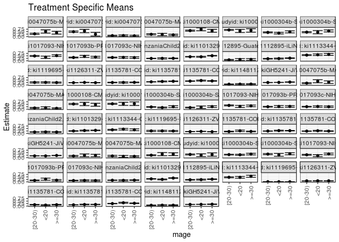

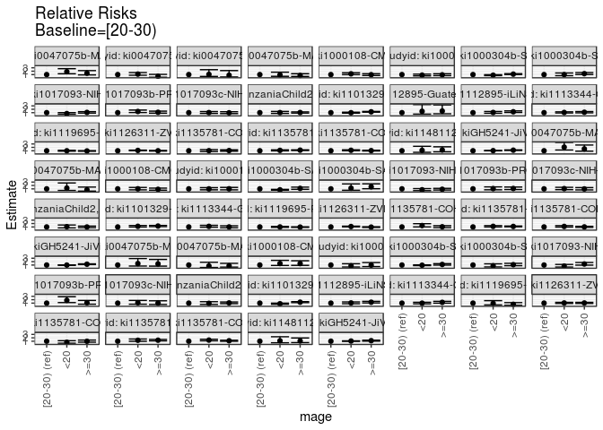

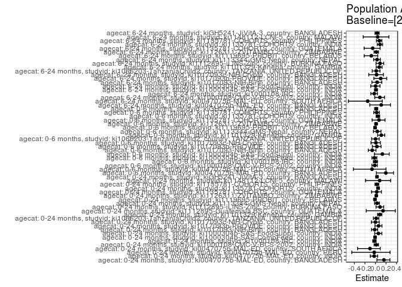

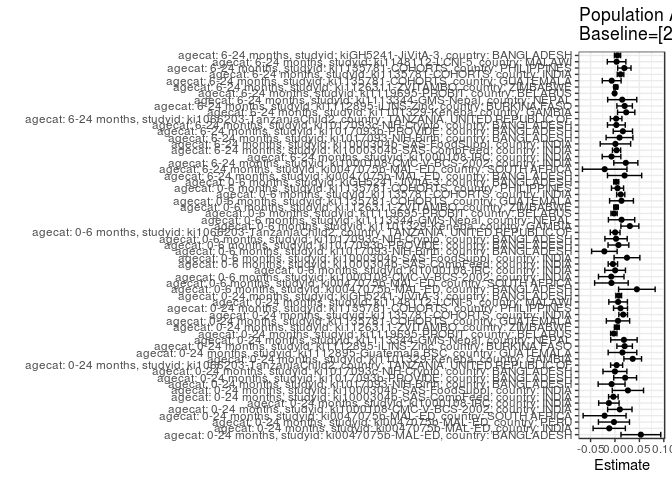

## Results Table

### Parameter: TSM

| agecat | studyid | country | intervention_level | baseline_level | estimate | ci_lower | ci_upper |
| --- | --- | --- | --- | --- | --- | --- | --- |
| 0-24 months | ki0047075b-MAL-ED | BANGLADESH | [20-30) | NA | 0.2777778 | 0.2122201 | 0.3433354 |
| 0-24 months | ki0047075b-MAL-ED | BANGLADESH | <20 | NA | 0.5135135 | 0.3521573 | 0.6748698 |
| 0-24 months | ki0047075b-MAL-ED | BANGLADESH | >=30 | NA | 0.3913043 | 0.2500005 | 0.5326081 |
| 0-24 months | ki0047075b-MAL-ED | INDIA | [20-30) | NA | 0.4896907 | 0.4192054 | 0.5601761 |
| 0-24 months | ki0047075b-MAL-ED | INDIA | <20 | NA | 0.5588235 | 0.3915890 | 0.7260581 |
| 0-24 months | ki0047075b-MAL-ED | INDIA | >=30 | NA | 0.2380952 | 0.0555637 | 0.4206268 |
| 0-24 months | ki0047075b-MAL-ED | PERU | [20-30) | NA | 0.0915033 | 0.0457415 | 0.1372650 |
| 0-24 months | ki0047075b-MAL-ED | PERU | <20 | NA | 0.0975610 | 0.0332317 | 0.1618902 |
| 0-24 months | ki0047075b-MAL-ED | PERU | >=30 | NA | 0.0746269 | 0.0115984 | 0.1376554 |
| 0-24 months | ki0047075b-MAL-ED | SOUTH AFRICA | [20-30) | NA | 0.2264151 | 0.1612593 | 0.2915709 |
| 0-24 months | ki0047075b-MAL-ED | SOUTH AFRICA | <20 | NA | 0.2083333 | 0.0932599 | 0.3234068 |
| 0-24 months | ki0047075b-MAL-ED | SOUTH AFRICA | >=30 | NA | 0.1714286 | 0.0992253 | 0.2436319 |
| 0-24 months | ki1000108-CMC-V-BCS-2002 | INDIA | [20-30) | NA | 0.6013514 | 0.5454986 | 0.6572041 |
| 0-24 months | ki1000108-CMC-V-BCS-2002 | INDIA | <20 | NA | 0.7352941 | 0.5868018 | 0.8837864 |
| 0-24 months | ki1000108-CMC-V-BCS-2002 | INDIA | >=30 | NA | 0.5813953 | 0.4337450 | 0.7290457 |
| 0-24 months | ki1000108-IRC | INDIA | [20-30) | NA | 0.6686047 | 0.6188015 | 0.7184078 |
| 0-24 months | ki1000108-IRC | INDIA | <20 | NA | 0.5675676 | 0.4077423 | 0.7273928 |
| 0-24 months | ki1000108-IRC | INDIA | >=30 | NA | 0.6206897 | 0.4438767 | 0.7975026 |
| 0-24 months | ki1000304b-SAS-CompFeed | INDIA | [20-30) | NA | 0.4184028 | 0.3690272 | 0.4677784 |
| 0-24 months | ki1000304b-SAS-CompFeed | INDIA | <20 | NA | 0.3437500 | 0.2634334 | 0.4240666 |
| 0-24 months | ki1000304b-SAS-CompFeed | INDIA | >=30 | NA | 0.4733728 | 0.3676148 | 0.5791308 |
| 0-24 months | ki1000304b-SAS-FoodSuppl | INDIA | [20-30) | NA | 0.4448276 | 0.3875639 | 0.5020912 |
| 0-24 months | ki1000304b-SAS-FoodSuppl | INDIA | <20 | NA | 0.4444444 | 0.2819309 | 0.6069579 |
| 0-24 months | ki1000304b-SAS-FoodSuppl | INDIA | >=30 | NA | 0.5652174 | 0.4637987 | 0.6666361 |
| 0-24 months | ki1017093-NIH-Birth | BANGLADESH | [20-30) | NA | 0.4844125 | 0.4364073 | 0.5324177 |
| 0-24 months | ki1017093-NIH-Birth | BANGLADESH | <20 | NA | 0.3561644 | 0.2462261 | 0.4661026 |
| 0-24 months | ki1017093-NIH-Birth | BANGLADESH | >=30 | NA | 0.5227273 | 0.4374504 | 0.6080042 |
| 0-24 months | ki1017093b-PROVIDE | BANGLADESH | [20-30) | NA | 0.3306288 | 0.2890723 | 0.3721853 |
| 0-24 months | ki1017093b-PROVIDE | BANGLADESH | <20 | NA | 0.4470588 | 0.3412868 | 0.5528309 |
| 0-24 months | ki1017093b-PROVIDE | BANGLADESH | >=30 | NA | 0.3688525 | 0.2831742 | 0.4545307 |

[output cut: 153 more lines]

### Parameter: E(Y)

| agecat | studyid | country | intervention_level | baseline_level | estimate | ci_lower | ci_upper |
| --- | --- | --- | --- | --- | --- | --- | --- |
| 0-24 months | ki0047075b-MAL-ED | BANGLADESH | NA | NA | 0.3307985 | 0.2738270 | 0.3877700 |
| 0-24 months | ki0047075b-MAL-ED | INDIA | NA | NA | 0.4779116 | 0.4157435 | 0.5400798 |
| 0-24 months | ki0047075b-MAL-ED | PERU | NA | NA | 0.0894040 | 0.0571706 | 0.1216374 |
| 0-24 months | ki0047075b-MAL-ED | SOUTH AFRICA | NA | NA | 0.2051282 | 0.1602507 | 0.2500058 |
| 0-24 months | ki1000108-CMC-V-BCS-2002 | INDIA | NA | NA | 0.6112601 | 0.5617242 | 0.6607959 |
| 0-24 months | ki1000108-IRC | INDIA | NA | NA | 0.6560976 | 0.6100625 | 0.7021326 |
| 0-24 months | ki1000304b-SAS-CompFeed | INDIA | NA | NA | 0.4150694 | 0.3581204 | 0.4720184 |
| 0-24 months | ki1000304b-SAS-FoodSuppl | INDIA | NA | NA | 0.4712919 | 0.4233811 | 0.5192026 |
| 0-24 months | ki1017093-NIH-Birth | BANGLADESH | NA | NA | 0.4774920 | 0.4382065 | 0.5167774 |
| 0-24 months | ki1017093b-PROVIDE | BANGLADESH | NA | NA | 0.3514286 | 0.3160364 | 0.3868207 |
| 0-24 months | ki1017093c-NIH-Crypto | BANGLADESH | NA | NA | 0.3298153 | 0.2963239 | 0.3633067 |
| 0-24 months | ki1066203-TanzaniaChild2 | TANZANIA, UNITED REPUBLIC OF | NA | NA | 0.2369529 | 0.2198518 | 0.2540539 |
| 0-24 months | ki1101329-Keneba | GAMBIA | NA | NA | 0.4437849 | 0.4255860 | 0.4619838 |
| 0-24 months | ki1112895-Guatemala BSC | GUATEMALA | NA | NA | 0.1067616 | 0.0705906 | 0.1429325 |
| 0-24 months | ki1112895-iLiNS-Zinc | BURKINA FASO | NA | NA | 0.2274300 | 0.2005343 | 0.2543257 |
| 0-24 months | ki1113344-GMS-Nepal | NEPAL | NA | NA | 0.5903790 | 0.5535526 | 0.6272054 |
| 0-24 months | ki1119695-PROBIT | BELARUS | NA | NA | 0.2565984 | 0.1993515 | 0.3138454 |
| 0-24 months | ki1126311-ZVITAMBO | ZIMBABWE | NA | NA | 0.2365545 | 0.2294916 | 0.2436174 |
| 0-24 months | ki1135781-COHORTS | GUATEMALA | NA | NA | 0.2550336 | 0.2316956 | 0.2783715 |
| 0-24 months | ki1135781-COHORTS | INDIA | NA | NA | 0.3359095 | 0.3231988 | 0.3486203 |
| 0-24 months | ki1135781-COHORTS | PHILIPPINES | NA | NA | 0.4036125 | 0.3861835 | 0.4210415 |
| 0-24 months | ki1148112-LCNI-5 | MALAWI | NA | NA | 0.0805970 | 0.0599695 | 0.1012246 |
| 0-24 months | kiGH5241-JiVitA-3 | BANGLADESH | NA | NA | 0.2580813 | 0.2516131 | 0.2645495 |
| 0-6 months | ki0047075b-MAL-ED | BANGLADESH | NA | NA | 0.2281369 | 0.1773250 | 0.2789488 |
| 0-6 months | ki0047075b-MAL-ED | SOUTH AFRICA | NA | NA | 0.1121795 | 0.0771053 | 0.1472536 |
| 0-6 months | ki1000108-CMC-V-BCS-2002 | INDIA | NA | NA | 0.5163043 | 0.4651769 | 0.5674318 |
| 0-6 months | ki1000108-IRC | INDIA | NA | NA | 0.5439024 | 0.4956326 | 0.5921723 |
| 0-6 months | ki1000304b-SAS-CompFeed | INDIA | NA | NA | 0.2199336 | 0.1753445 | 0.2645227 |
| 0-6 months | ki1000304b-SAS-FoodSuppl | INDIA | NA | NA | 0.1866029 | 0.1492099 | 0.2239959 |
| 0-6 months | ki1017093-NIH-Birth | BANGLADESH | NA | NA | 0.3580645 | 0.3202961 | 0.3958330 |
| 0-6 months | ki1017093b-PROVIDE | BANGLADESH | NA | NA | 0.2585714 | 0.2261125 | 0.2910304 |
| 0-6 months | ki1017093c-NIH-Crypto | BANGLADESH | NA | NA | 0.2572559 | 0.2261171 | 0.2883948 |
| 0-6 months | ki1066203-TanzaniaChild2 | TANZANIA, UNITED REPUBLIC OF | NA | NA | 0.1397306 | 0.1257869 | 0.1536744 |
| 0-6 months | ki1101329-Keneba | GAMBIA | NA | NA | 0.2749591 | 0.2572539 | 0.2926643 |
| 0-6 months | ki1113344-GMS-Nepal | NEPAL | NA | NA | 0.3760933 | 0.3398180 | 0.4123685 |
| 0-6 months | ki1119695-PROBIT | BELARUS | NA | NA | 0.2497780 | 0.1917926 | 0.3077635 |
| 0-6 months | ki1126311-ZVITAMBO | ZIMBABWE | NA | NA | 0.1808903 | 0.1744713 | 0.1873093 |
| 0-6 months | ki1135781-COHORTS | GUATEMALA | NA | NA | 0.2003763 | 0.1763021 | 0.2244505 |
| 0-6 months | ki1135781-COHORTS | INDIA | NA | NA | 0.2500980 | 0.2382136 | 0.2619824 |
| 0-6 months | ki1135781-COHORTS | PHILIPPINES | NA | NA | 0.2355453 | 0.2204685 | 0.2506222 |
| 0-6 months | kiGH5241-JiVitA-3 | BANGLADESH | NA | NA | 0.1762142 | 0.1705882 | 0.1818403 |
| 6-24 months | ki0047075b-MAL-ED | BANGLADESH | NA | NA | 0.1791667 | 0.1305478 | 0.2277856 |
| 6-24 months | ki0047075b-MAL-ED | SOUTH AFRICA | NA | NA | 0.1428571 | 0.1001583 | 0.1855560 |
| 6-24 months | ki1000108-CMC-V-BCS-2002 | INDIA | NA | NA | 0.2654155 | 0.2205451 | 0.3102860 |
| 6-24 months | ki1000108-IRC | INDIA | NA | NA | 0.3097561 | 0.2649438 | 0.3545684 |
| 6-24 months | ki1000304b-SAS-CompFeed | INDIA | NA | NA | 0.3059755 | 0.2638053 | 0.3481458 |
| 6-24 months | ki1000304b-SAS-FoodSuppl | INDIA | NA | NA | 0.3557214 | 0.3088651 | 0.4025777 |
| 6-24 months | ki1017093-NIH-Birth | BANGLADESH | NA | NA | 0.2925926 | 0.2541847 | 0.3310005 |
| 6-24 months | ki1017093b-PROVIDE | BANGLADESH | NA | NA | 0.1609756 | 0.1319065 | 0.1900447 |
| 6-24 months | ki1017093c-NIH-Crypto | BANGLADESH | NA | NA | 0.1315068 | 0.1069744 | 0.1560393 |
| 6-24 months | ki1066203-TanzaniaChild2 | TANZANIA, UNITED REPUBLIC OF | NA | NA | 0.1607589 | 0.1446692 | 0.1768485 |
| 6-24 months | ki1101329-Keneba | GAMBIA | NA | NA | 0.3201934 | 0.3025561 | 0.3378307 |
| 6-24 months | ki1112895-iLiNS-Zinc | BURKINA FASO | NA | NA | 0.2274300 | 0.2005343 | 0.2543257 |
| 6-24 months | ki1113344-GMS-Nepal | NEPAL | NA | NA | 0.4728814 | 0.4325613 | 0.5132014 |
| 6-24 months | ki1119695-PROBIT | BELARUS | NA | NA | 0.0100615 | 0.0072668 | 0.0128561 |
| 6-24 months | ki1126311-ZVITAMBO | ZIMBABWE | NA | NA | 0.0959310 | 0.0903738 | 0.1014883 |
| 6-24 months | ki1135781-COHORTS | GUATEMALA | NA | NA | 0.1269580 | 0.1082147 | 0.1457012 |
| 6-24 months | ki1135781-COHORTS | INDIA | NA | NA | 0.1317329 | 0.1223171 | 0.1411487 |
| 6-24 months | ki1135781-COHORTS | PHILIPPINES | NA | NA | 0.2666429 | 0.2502871 | 0.2829988 |
| 6-24 months | ki1148112-LCNI-5 | MALAWI | NA | NA | 0.0789074 | 0.0583085 | 0.0995064 |
| 6-24 months | kiGH5241-JiVitA-3 | BANGLADESH | NA | NA | 0.1640643 | 0.1579507 | 0.1701779 |

### Parameter: RR

| agecat | studyid | country | intervention_level | baseline_level | estimate | ci_lower | ci_upper |
| --- | --- | --- | --- | --- | --- | --- | --- |
| 0-24 months | ki0047075b-MAL-ED | BANGLADESH | [20-30) | [20-30) | 1.0000000 | 1.0000000 | 1.0000000 |
| 0-24 months | ki0047075b-MAL-ED | BANGLADESH | <20 | [20-30) | 1.8486486 | 1.2479152 | 2.7385690 |
| 0-24 months | ki0047075b-MAL-ED | BANGLADESH | >=30 | [20-30) | 1.4086957 | 0.9150939 | 2.1685462 |
| 0-24 months | ki0047075b-MAL-ED | INDIA | [20-30) | [20-30) | 1.0000000 | 1.0000000 | 1.0000000 |
| 0-24 months | ki0047075b-MAL-ED | INDIA | <20 | [20-30) | 1.1411765 | 0.8187157 | 1.5906423 |
| 0-24 months | ki0047075b-MAL-ED | INDIA | >=30 | [20-30) | 0.4862155 | 0.2228779 | 1.0606955 |
| 0-24 months | ki0047075b-MAL-ED | PERU | [20-30) | [20-30) | 1.0000000 | 1.0000000 | 1.0000000 |
| 0-24 months | ki0047075b-MAL-ED | PERU | <20 | [20-30) | 1.0662021 | 0.4660440 | 2.4392264 |
| 0-24 months | ki0047075b-MAL-ED | PERU | >=30 | [20-30) | 0.8155650 | 0.3056183 | 2.1763956 |
| 0-24 months | ki0047075b-MAL-ED | SOUTH AFRICA | [20-30) | [20-30) | 1.0000000 | 1.0000000 | 1.0000000 |
| 0-24 months | ki0047075b-MAL-ED | SOUTH AFRICA | <20 | [20-30) | 0.9201389 | 0.4935893 | 1.7153038 |
| 0-24 months | ki0047075b-MAL-ED | SOUTH AFRICA | >=30 | [20-30) | 0.7571429 | 0.4546119 | 1.2609995 |
| 0-24 months | ki1000108-CMC-V-BCS-2002 | INDIA | [20-30) | [20-30) | 1.0000000 | 1.0000000 | 1.0000000 |
| 0-24 months | ki1000108-CMC-V-BCS-2002 | INDIA | <20 | [20-30) | 1.2227363 | 0.9790304 | 1.5271068 |
| 0-24 months | ki1000108-CMC-V-BCS-2002 | INDIA | >=30 | [20-30) | 0.9668147 | 0.7377441 | 1.2670121 |
| 0-24 months | ki1000108-IRC | INDIA | [20-30) | [20-30) | 1.0000000 | 1.0000000 | 1.0000000 |
| 0-24 months | ki1000108-IRC | INDIA | <20 | [20-30) | 0.8488837 | 0.6343748 | 1.1359270 |
| 0-24 months | ki1000108-IRC | INDIA | >=30 | [20-30) | 0.9283358 | 0.6915604 | 1.2461781 |
| 0-24 months | ki1000304b-SAS-CompFeed | INDIA | [20-30) | [20-30) | 1.0000000 | 1.0000000 | 1.0000000 |
| 0-24 months | ki1000304b-SAS-CompFeed | INDIA | <20 | [20-30) | 0.8215768 | 0.7004297 | 0.9636775 |
| 0-24 months | ki1000304b-SAS-CompFeed | INDIA | >=30 | [20-30) | 1.1313806 | 0.9932841 | 1.2886767 |
| 0-24 months | ki1000304b-SAS-FoodSuppl | INDIA | [20-30) | [20-30) | 1.0000000 | 1.0000000 | 1.0000000 |
| 0-24 months | ki1000304b-SAS-FoodSuppl | INDIA | <20 | [20-30) | 0.9991387 | 0.6780624 | 1.4722511 |
| 0-24 months | ki1000304b-SAS-FoodSuppl | INDIA | >=30 | [20-30) | 1.2706437 | 1.0188641 | 1.5846427 |
| 0-24 months | ki1017093-NIH-Birth | BANGLADESH | [20-30) | [20-30) | 1.0000000 | 1.0000000 | 1.0000000 |
| 0-24 months | ki1017093-NIH-Birth | BANGLADESH | <20 | [20-30) | 0.7352502 | 0.5316685 | 1.0167857 |
| 0-24 months | ki1017093-NIH-Birth | BANGLADESH | >=30 | [20-30) | 1.0790954 | 0.8915835 | 1.3060436 |
| 0-24 months | ki1017093b-PROVIDE | BANGLADESH | [20-30) | [20-30) | 1.0000000 | 1.0000000 | 1.0000000 |
| 0-24 months | ki1017093b-PROVIDE | BANGLADESH | <20 | [20-30) | 1.3521472 | 1.0343622 | 1.7675647 |
| 0-24 months | ki1017093b-PROVIDE | BANGLADESH | >=30 | [20-30) | 1.1156090 | 0.8566653 | 1.4528234 |

[output cut: 153 more lines]

### Parameter: PAR

| agecat | studyid | country | intervention_level | baseline_level | estimate | ci_lower | ci_upper |
| --- | --- | --- | --- | --- | --- | --- | --- |
| 0-24 months | ki0047075b-MAL-ED | BANGLADESH | [20-30) | NA | 0.0530207 | 0.0122699 | 0.0937715 |
| 0-24 months | ki0047075b-MAL-ED | INDIA | [20-30) | NA | -0.0117791 | -0.0448166 | 0.0212585 |
| 0-24 months | ki0047075b-MAL-ED | PERU | [20-30) | NA | -0.0020993 | -0.0338995 | 0.0297009 |
| 0-24 months | ki0047075b-MAL-ED | SOUTH AFRICA | [20-30) | NA | -0.0212869 | -0.0652454 | 0.0226717 |
| 0-24 months | ki1000108-CMC-V-BCS-2002 | INDIA | [20-30) | NA | 0.0099087 | -0.0150357 | 0.0348531 |
| 0-24 months | ki1000108-IRC | INDIA | [20-30) | NA | -0.0125071 | -0.0334217 | 0.0084075 |
| 0-24 months | ki1000304b-SAS-CompFeed | INDIA | [20-30) | NA | -0.0033334 | -0.0131339 | 0.0064672 |
| 0-24 months | ki1000304b-SAS-FoodSuppl | INDIA | [20-30) | NA | 0.0264643 | -0.0055448 | 0.0584734 |
| 0-24 months | ki1017093-NIH-Birth | BANGLADESH | [20-30) | NA | -0.0069205 | -0.0344503 | 0.0206093 |
| 0-24 months | ki1017093b-PROVIDE | BANGLADESH | [20-30) | NA | 0.0207998 | -0.0025888 | 0.0441883 |
| 0-24 months | ki1017093c-NIH-Crypto | BANGLADESH | [20-30) | NA | -0.0001442 | -0.0246252 | 0.0243368 |
| 0-24 months | ki1066203-TanzaniaChild2 | TANZANIA, UNITED REPUBLIC OF | [20-30) | NA | 0.0033437 | -0.0089546 | 0.0156420 |
| 0-24 months | ki1101329-Keneba | GAMBIA | [20-30) | NA | 0.0363005 | 0.0182378 | 0.0543632 |
| 0-24 months | ki1112895-Guatemala BSC | GUATEMALA | [20-30) | NA | 0.0153330 | -0.0139754 | 0.0446414 |
| 0-24 months | ki1112895-iLiNS-Zinc | BURKINA FASO | [20-30) | NA | 0.0197421 | 0.0039116 | 0.0355727 |
| 0-24 months | ki1113344-GMS-Nepal | NEPAL | [20-30) | NA | 0.0183069 | -0.0087411 | 0.0453549 |
| 0-24 months | ki1119695-PROBIT | BELARUS | [20-30) | NA | -0.0024288 | -0.0088999 | 0.0040423 |
| 0-24 months | ki1126311-ZVITAMBO | ZIMBABWE | [20-30) | NA | 0.0037452 | -0.0012138 | 0.0087042 |
| 0-24 months | ki1135781-COHORTS | GUATEMALA | [20-30) | NA | 0.0061786 | -0.0176965 | 0.0300537 |
| 0-24 months | ki1135781-COHORTS | INDIA | [20-30) | NA | 0.0167547 | 0.0078713 | 0.0256381 |
| 0-24 months | ki1135781-COHORTS | PHILIPPINES | [20-30) | NA | 0.0113048 | -0.0030274 | 0.0256370 |
| 0-24 months | ki1148112-LCNI-5 | MALAWI | [20-30) | NA | 0.0064212 | -0.0126225 | 0.0254649 |
| 0-24 months | kiGH5241-JiVitA-3 | BANGLADESH | [20-30) | NA | 0.0076444 | 0.0017773 | 0.0135116 |
| 0-6 months | ki0047075b-MAL-ED | BANGLADESH | [20-30) | NA | 0.0448035 | 0.0074022 | 0.0822049 |
| 0-6 months | ki0047075b-MAL-ED | SOUTH AFRICA | [20-30) | NA | -0.0073174 | -0.0416853 | 0.0270505 |
| 0-6 months | ki1000108-CMC-V-BCS-2002 | INDIA | [20-30) | NA | -0.0076683 | -0.0337978 | 0.0184613 |
| 0-6 months | ki1000108-IRC | INDIA | [20-30) | NA | 0.0002978 | -0.0208406 | 0.0214362 |
| 0-6 months | ki1000304b-SAS-CompFeed | INDIA | [20-30) | NA | -0.0043247 | -0.0139338 | 0.0052843 |
| 0-6 months | ki1000304b-SAS-FoodSuppl | INDIA | [20-30) | NA | 0.0245339 | -0.0019120 | 0.0509798 |
| 0-6 months | ki1017093-NIH-Birth | BANGLADESH | [20-30) | NA | -0.0217432 | -0.0478485 | 0.0043621 |
| 0-6 months | ki1017093b-PROVIDE | BANGLADESH | [20-30) | NA | 0.0070501 | -0.0142428 | 0.0283430 |
| 0-6 months | ki1017093c-NIH-Crypto | BANGLADESH | [20-30) | NA | 0.0021952 | -0.0206239 | 0.0250143 |
| 0-6 months | ki1066203-TanzaniaChild2 | TANZANIA, UNITED REPUBLIC OF | [20-30) | NA | 0.0003290 | -0.0096617 | 0.0103197 |
| 0-6 months | ki1101329-Keneba | GAMBIA | [20-30) | NA | 0.0304957 | 0.0121320 | 0.0488594 |
| 0-6 months | ki1113344-GMS-Nepal | NEPAL | [20-30) | NA | 0.0134807 | -0.0134676 | 0.0404289 |
| 0-6 months | ki1119695-PROBIT | BELARUS | [20-30) | NA | -0.0018503 | -0.0081943 | 0.0044937 |
| 0-6 months | ki1126311-ZVITAMBO | ZIMBABWE | [20-30) | NA | 0.0021230 | -0.0023734 | 0.0066194 |
| 0-6 months | ki1135781-COHORTS | GUATEMALA | [20-30) | NA | 0.0133534 | -0.0110456 | 0.0377524 |
| 0-6 months | ki1135781-COHORTS | INDIA | [20-30) | NA | 0.0117964 | 0.0034718 | 0.0201210 |
| 0-6 months | ki1135781-COHORTS | PHILIPPINES | [20-30) | NA | 0.0051990 | -0.0072198 | 0.0176178 |
| 0-6 months | kiGH5241-JiVitA-3 | BANGLADESH | [20-30) | NA | 0.0025506 | -0.0026319 | 0.0077331 |
| 6-24 months | ki0047075b-MAL-ED | BANGLADESH | [20-30) | NA | 0.0196575 | -0.0153694 | 0.0546844 |
| 6-24 months | ki0047075b-MAL-ED | SOUTH AFRICA | [20-30) | NA | -0.0210773 | -0.0666196 | 0.0244650 |
| 6-24 months | ki1000108-CMC-V-BCS-2002 | INDIA | [20-30) | NA | 0.0221723 | -0.0024646 | 0.0468093 |
| 6-24 months | ki1000108-IRC | INDIA | [20-30) | NA | -0.0071044 | -0.0262133 | 0.0120045 |
| 6-24 months | ki1000304b-SAS-CompFeed | INDIA | [20-30) | NA | 0.0032319 | -0.0051820 | 0.0116458 |
| 6-24 months | ki1000304b-SAS-FoodSuppl | INDIA | [20-30) | NA | 0.0008827 | -0.0302506 | 0.0320160 |
| 6-24 months | ki1017093-NIH-Birth | BANGLADESH | [20-30) | NA | 0.0092593 | -0.0181556 | 0.0366741 |
| 6-24 months | ki1017093b-PROVIDE | BANGLADESH | [20-30) | NA | 0.0161480 | -0.0036200 | 0.0359160 |
| 6-24 months | ki1017093c-NIH-Crypto | BANGLADESH | [20-30) | NA | 0.0028149 | -0.0153536 | 0.0209833 |
| 6-24 months | ki1066203-TanzaniaChild2 | TANZANIA, UNITED REPUBLIC OF | [20-30) | NA | 0.0023809 | -0.0094221 | 0.0141839 |
| 6-24 months | ki1101329-Keneba | GAMBIA | [20-30) | NA | 0.0229566 | 0.0052499 | 0.0406633 |
| 6-24 months | ki1112895-iLiNS-Zinc | BURKINA FASO | [20-30) | NA | 0.0197421 | 0.0039116 | 0.0355727 |
| 6-24 months | ki1113344-GMS-Nepal | NEPAL | [20-30) | NA | 0.0147662 | -0.0150370 | 0.0445693 |
| 6-24 months | ki1119695-PROBIT | BELARUS | [20-30) | NA | -0.0007844 | -0.0019914 | 0.0004227 |
| 6-24 months | ki1126311-ZVITAMBO | ZIMBABWE | [20-30) | NA | 0.0015468 | -0.0024099 | 0.0055036 |
| 6-24 months | ki1135781-COHORTS | GUATEMALA | [20-30) | NA | -0.0067138 | -0.0259638 | 0.0125362 |
| 6-24 months | ki1135781-COHORTS | INDIA | [20-30) | NA | 0.0113763 | 0.0046369 | 0.0181156 |
| 6-24 months | ki1135781-COHORTS | PHILIPPINES | [20-30) | NA | 0.0191833 | 0.0055547 | 0.0328119 |
| 6-24 months | ki1148112-LCNI-5 | MALAWI | [20-30) | NA | 0.0032772 | -0.0157344 | 0.0222887 |
| 6-24 months | kiGH5241-JiVitA-3 | BANGLADESH | [20-30) | NA | 0.0052251 | -0.0011319 | 0.0115820 |

### Parameter: PAF

| agecat | studyid | country | intervention_level | baseline_level | estimate | ci_lower | ci_upper |
| --- | --- | --- | --- | --- | --- | --- | --- |
| 0-24 months | ki0047075b-MAL-ED | BANGLADESH | [20-30) | NA | 0.1602810 | 0.0282063 | 0.2744056 |
| 0-24 months | ki0047075b-MAL-ED | INDIA | [20-30) | NA | -0.0246470 | -0.0962308 | 0.0422625 |
| 0-24 months | ki0047075b-MAL-ED | PERU | [20-30) | NA | -0.0234810 | -0.4486935 | 0.2769255 |
| 0-24 months | ki0047075b-MAL-ED | SOUTH AFRICA | [20-30) | NA | -0.1037736 | -0.3396598 | 0.0905780 |
| 0-24 months | ki1000108-CMC-V-BCS-2002 | INDIA | [20-30) | NA | 0.0162103 | -0.0255022 | 0.0562261 |
| 0-24 months | ki1000108-IRC | INDIA | [20-30) | NA | -0.0190629 | -0.0515274 | 0.0123994 |
| 0-24 months | ki1000304b-SAS-CompFeed | INDIA | [20-30) | NA | -0.0080309 | -0.0328414 | 0.0161836 |
| 0-24 months | ki1000304b-SAS-FoodSuppl | INDIA | [20-30) | NA | 0.0561526 | -0.0144443 | 0.1218366 |
| 0-24 months | ki1017093-NIH-Birth | BANGLADESH | [20-30) | NA | -0.0144935 | -0.0738294 | 0.0415638 |
| 0-24 months | ki1017093b-PROVIDE | BANGLADESH | [20-30) | NA | 0.0591863 | -0.0097826 | 0.1234446 |
| 0-24 months | ki1017093c-NIH-Crypto | BANGLADESH | [20-30) | NA | -0.0004372 | -0.0774866 | 0.0711024 |
| 0-24 months | ki1066203-TanzaniaChild2 | TANZANIA, UNITED REPUBLIC OF | [20-30) | NA | 0.0141112 | -0.0391772 | 0.0646671 |
| 0-24 months | ki1101329-Keneba | GAMBIA | [20-30) | NA | 0.0817975 | 0.0401133 | 0.1216715 |
| 0-24 months | ki1112895-Guatemala BSC | GUATEMALA | [20-30) | NA | 0.1436190 | -0.1752619 | 0.3759788 |
| 0-24 months | ki1112895-iLiNS-Zinc | BURKINA FASO | [20-30) | NA | 0.0868052 | 0.0110363 | 0.1567691 |
| 0-24 months | ki1113344-GMS-Nepal | NEPAL | [20-30) | NA | 0.0310088 | -0.0159829 | 0.0758270 |
| 0-24 months | ki1119695-PROBIT | BELARUS | [20-30) | NA | -0.0094653 | -0.0345870 | 0.0150463 |
| 0-24 months | ki1126311-ZVITAMBO | ZIMBABWE | [20-30) | NA | 0.0158322 | -0.0053541 | 0.0365720 |
| 0-24 months | ki1135781-COHORTS | GUATEMALA | [20-30) | NA | 0.0242266 | -0.0740173 | 0.1134838 |
| 0-24 months | ki1135781-COHORTS | INDIA | [20-30) | NA | 0.0498785 | 0.0230639 | 0.0759571 |
| 0-24 months | ki1135781-COHORTS | PHILIPPINES | [20-30) | NA | 0.0280090 | -0.0081642 | 0.0628843 |
| 0-24 months | ki1148112-LCNI-5 | MALAWI | [20-30) | NA | 0.0796703 | -0.1887603 | 0.2874874 |
| 0-24 months | kiGH5241-JiVitA-3 | BANGLADESH | [20-30) | NA | 0.0296202 | 0.0065881 | 0.0521184 |
| 0-6 months | ki0047075b-MAL-ED | BANGLADESH | [20-30) | NA | 0.1963889 | 0.0183109 | 0.3421636 |
| 0-6 months | ki0047075b-MAL-ED | SOUTH AFRICA | [20-30) | NA | -0.0652291 | -0.4195344 | 0.2006442 |
| 0-6 months | ki1000108-CMC-V-BCS-2002 | INDIA | [20-30) | NA | -0.0148522 | -0.0667703 | 0.0345391 |
| 0-6 months | ki1000108-IRC | INDIA | [20-30) | NA | 0.0005475 | -0.0390824 | 0.0386660 |
| 0-6 months | ki1000304b-SAS-CompFeed | INDIA | [20-30) | NA | -0.0196638 | -0.0674585 | 0.0259908 |
| 0-6 months | ki1000304b-SAS-FoodSuppl | INDIA | [20-30) | NA | 0.1314766 | -0.0207230 | 0.2609817 |
| 0-6 months | ki1017093-NIH-Birth | BANGLADESH | [20-30) | NA | -0.0607242 | -0.1362500 | 0.0097815 |
| 0-6 months | ki1017093b-PROVIDE | BANGLADESH | [20-30) | NA | 0.0272657 | -0.0586438 | 0.1062036 |
| 0-6 months | ki1017093c-NIH-Crypto | BANGLADESH | [20-30) | NA | 0.0085332 | -0.0842556 | 0.0933812 |
| 0-6 months | ki1066203-TanzaniaChild2 | TANZANIA, UNITED REPUBLIC OF | [20-30) | NA | 0.0023544 | -0.0717696 | 0.0713520 |
| 0-6 months | ki1101329-Keneba | GAMBIA | [20-30) | NA | 0.1109100 | 0.0416848 | 0.1751346 |
| 0-6 months | ki1113344-GMS-Nepal | NEPAL | [20-30) | NA | 0.0358440 | -0.0385534 | 0.1049119 |
| 0-6 months | ki1119695-PROBIT | BELARUS | [20-30) | NA | -0.0074077 | -0.0327611 | 0.0173232 |
| 0-6 months | ki1126311-ZVITAMBO | ZIMBABWE | [20-30) | NA | 0.0117363 | -0.0134340 | 0.0362815 |
| 0-6 months | ki1135781-COHORTS | GUATEMALA | [20-30) | NA | 0.0666416 | -0.0632643 | 0.1806760 |
| 0-6 months | ki1135781-COHORTS | INDIA | [20-30) | NA | 0.0471673 | 0.0133222 | 0.0798514 |
| 0-6 months | ki1135781-COHORTS | PHILIPPINES | [20-30) | NA | 0.0220721 | -0.0320907 | 0.0733926 |
| 0-6 months | kiGH5241-JiVitA-3 | BANGLADESH | [20-30) | NA | 0.0144743 | -0.0153853 | 0.0434558 |
| 6-24 months | ki0047075b-MAL-ED | BANGLADESH | [20-30) | NA | 0.1097161 | -0.1071782 | 0.2841211 |
| 6-24 months | ki0047075b-MAL-ED | SOUTH AFRICA | [20-30) | NA | -0.1475410 | -0.5125291 | 0.1293719 |
| 6-24 months | ki1000108-CMC-V-BCS-2002 | INDIA | [20-30) | NA | 0.0835381 | -0.0137474 | 0.1714875 |
| 6-24 months | ki1000108-IRC | INDIA | [20-30) | NA | -0.0229354 | -0.0865158 | 0.0369245 |
| 6-24 months | ki1000304b-SAS-CompFeed | INDIA | [20-30) | NA | 0.0105626 | -0.0166411 | 0.0370385 |
| 6-24 months | ki1000304b-SAS-FoodSuppl | INDIA | [20-30) | NA | 0.0024814 | -0.0889946 | 0.0862733 |
| 6-24 months | ki1017093-NIH-Birth | BANGLADESH | [20-30) | NA | 0.0316456 | -0.0667134 | 0.1209351 |
| 6-24 months | ki1017093b-PROVIDE | BANGLADESH | [20-30) | NA | 0.1003135 | -0.0302572 | 0.2143361 |
| 6-24 months | ki1017093c-NIH-Crypto | BANGLADESH | [20-30) | NA | 0.0214047 | -0.1269324 | 0.1502164 |
| 6-24 months | ki1066203-TanzaniaChild2 | TANZANIA, UNITED REPUBLIC OF | [20-30) | NA | 0.0148104 | -0.0614051 | 0.0855531 |
| 6-24 months | ki1101329-Keneba | GAMBIA | [20-30) | NA | 0.0716962 | 0.0147346 | 0.1253646 |
| 6-24 months | ki1112895-iLiNS-Zinc | BURKINA FASO | [20-30) | NA | 0.0868052 | 0.0110363 | 0.1567691 |
| 6-24 months | ki1113344-GMS-Nepal | NEPAL | [20-30) | NA | 0.0312260 | -0.0339381 | 0.0922831 |
| 6-24 months | ki1119695-PROBIT | BELARUS | [20-30) | NA | -0.0779561 | -0.2149091 | 0.0435586 |
| 6-24 months | ki1126311-ZVITAMBO | ZIMBABWE | [20-30) | NA | 0.0161244 | -0.0259894 | 0.0565096 |
| 6-24 months | ki1135781-COHORTS | GUATEMALA | [20-30) | NA | -0.0528820 | -0.2158068 | 0.0882100 |
| 6-24 months | ki1135781-COHORTS | INDIA | [20-30) | NA | 0.0863588 | 0.0340254 | 0.1358569 |
| 6-24 months | ki1135781-COHORTS | PHILIPPINES | [20-30) | NA | 0.0719437 | 0.0194636 | 0.1216150 |
| 6-24 months | ki1148112-LCNI-5 | MALAWI | [20-30) | NA | 0.0415320 | -0.2321283 | 0.2544113 |
| 6-24 months | kiGH5241-JiVitA-3 | BANGLADESH | [20-30) | NA | 0.0318476 | -0.0076445 | 0.0697919 |